# Physical Activity Level and Performance of Pelvic Floor Muscle Exercises

Zoe Gan

### Overview

Pelvic floor muscle (PFM) exercises are a non-invasive and effective treatment option for female pelvic floor disorders, but patient adherence is often poor, and predictors of adherence are limited. Our objective is to evaluate the relationship between physical activity level in women and performance of PFM exercises.

### Introduction

Pelvic floor muscle (PFM) exercises are an effective treatment for a variety of pelvic floor disorders (PFDs) in women, including urinary incontinence (UI), fecal incontinence, and symptomatic pelvic organ prolapse. They are often recommended by clinicians as an adjunct to medication in the case of overactive bladder or a non-invasive treatment option prior to considering surgery for stress UI. They may be done either at home or through formal pelvic floor physical therapy (PFPT) and are often known as Kegel exercises. However, compliance is poor, and the completion rate for women prescribed PFPT for PFDs has been cited at less than 50%(1). Poor compliance with PFM exercises may lead to missed opportunities for clinical improvement, which may ultimately subject patients to side effects from increased medication dosages or morbidity from surgical procedures.

Adherence to PFPT is an interdisciplinary issue and may be affected by several factors. Women recommended PFPT for treatment of UI most commonly cite boredom and forgetting do exercises as reasons for low adherence to PFPT(2). In a diverse, urban population of women prescribed PFPT, Hispanic women were less likely to initiate PFPT (3); age and nationality may also affect PFPT completion(1). These studies suggest that psychologic, cultural, and socioeconomic factors may play a role in performing PFPT. Given that enhanced patient counseling alone was not found to improve patient attendance at PFPT(4), there is a need to better understand the relationship between factors underlying non-adherence in order to design appropriate interventions. Physical activity has not previously been explored in this context.

Physical activity may influence performance of PFM exercises. Low baseline levels of physical activity have been associated with poor adherence to outpatient musculoskeletal physiotherapy(5). Patients with lower athletic identity, or identification with the athlete role, were shown to have lower participation in rehabilitation exercises on high-stress days after anterior cruciate ligament reconstruction(6). However, the relationship between physical activity and performance of PFM exercises specifically has not been explored. We explore the relationship between physical activity and performance of PFM exercises, hypothesizing that women who have higher levels of baseline physical activity perform PFM exercises more frequently than less active women.

### Methods

Women administered a cross-sectional survey through Research Match, a national online volunteer registry, were stratified into low, moderate, and high activity categories based on the International Physical Activity Questionnaire (IPAQ) Short Form. Reasons for starting Kegels or PFM exercises and sources of education about these exercises were described for the cohort. The primary outcome was the self-reported frequency of performing Kegels or PFM exercises compared between IPAQ groups. Secondary outcomes included whether women had previously heard of Kegel or PFM exercises and reasons for not performing these exercises more.

#### Importing Packages

```r
#install.packages("tidyverse")
#install.packages("dplyr")
#install.packages("ggplot2")
#install.packages("modelsummary")
#install.packages("viridis")
#install.packages("expss")
#install.packages("tableone")
#install.packages("labelled")
#install.packages("gtsummary")
#install.packages("webshot2")
#install.packages("MASS")
```

#### Loading Packages

```r
library(tidyverse)
```

```r
library(ggplot2)
library(viridis)
library(modelsummary)
library(expss)
library(tableone)
library(labelled)
library(gtsummary)
library(webshot2)
library(dplyr)
```

#### Reading in data

```r
bladderhealth.df <- read.csv("PennBladderHealthStu_DATA_2022-09-23_1043.csv")

#Remove email addresses
bladderhealth.df <- select(bladderhealth.df, -email) #1755 observations
```

#### Cleaning data

##### First assess gender distribution

```r
#Apply labels to gender categories
bladderhealth.df <- bladderhealth.df %>%
  mutate(demo_gender = factor(demo_gender, levels = c(1, 2, 3, 4, 5, 6, 7, 8), labels = c("Female", "Male", "Trans Female", "Trans Male", "Genderqueer", "Gender nonconforming", "Other", "Decline to Answer")))
table(bladderhealth.df$demo_gender)
```

```
##
##               Female                 Male         Trans Female
##                 1720                    7                    2
##           Trans Male          Genderqueer Gender nonconforming
##                    3                    6                    8
##                Other    Decline to Answer
##                    4                    1
```

```r
#For simplicity, will exclude all responses that are not "female" given unclear anatomy of subjects who are trans, genderqueer, or gender nonconforming.
bladderhealth.df <- bladderhealth.df %>%
  filter(demo_gender == "Female") #1720 observations
```

##### Plan to evaluate the following variables to see if they predict doing PFM exercises (univariate and multivariable models):

age (demo_age), bmi (bmi, NEED TO CREATE), gender (demo_gender), education level (demo_edu), race (demo_race), ethnicity (demo_hisp), smoking hx (demo_cig), insurance (demo_insurance), general health (health_gen), vaginal deliveries (repro_children), sexually active (sex_active), LURN-SI 29 score (lurnsi29, NEED TO CREATE), physical activity level (ipaq, NEED TO CREATE)

3 variables need to be created: bmi, lurnsi29, and ipaq. Will create ipaq variable first for comparing questionnaire item answers between physical activity categories, then create bmi and lurnsi29 variables for the linear regression analyses.

##### Format data to calculate IPAQ score (ipaq)

Will first evaluate all time variables. These are individual variables for minutes, hours, and days for each level of activity (low, moderate, and high) that will be used to calculate IPAQ score and subsequently determine IPAQ category (low, moderate, and high physical activity level). Before using these for the IPAQ score calculation, need to ensure they are the proper class and don’t have inaccurate outlying values (for example, >7 days of physical activity entered per week). IPAQ scoring guidelines also recommend a 15 hour per day cutoff for physical activity (and recoding such values to minutes instead, as they are assumed to have been erroneously entered in the “hours” category) and recoding any activity minute entries <10 minutes to 0 minutes and >180 minutes to 180 minutes (except for sitting time). Therefore, data cleaning is required before using the time variables for IPAQ score calculation.

```r
#Check class of time variables
class(bladderhealth.df$pa_66a_days)
```

```
## [1] "character"
```

```r
#Convert time variables from character to numeric
cols <- c("pa_66a_days", "pa_66b_hours", "pa_66b_minutes", "pa_67a_days", "pa_67b_hours", "pa_67b_minutes", "pa_68a_days", "pa_68b_hours", "pa_68b_minutes", "pa_69_hours", "pa_69_minutes")
suppressWarnings(bladderhealth.df[cols] <- sapply(bladderhealth.df[cols], as.numeric))
#Initially received a warning that NAs were introduced by coercion. This is ok for our purposes, so the warning has been suppressed.

#Confirm all time variables are now numeric.
sapply(bladderhealth.df[cols], class)
```

```
##    pa_66a_days   pa_66b_hours pa_66b_minutes    pa_67a_days   pa_67b_hours
##      "numeric"      "numeric"      "numeric"      "numeric"      "numeric"
## pa_67b_minutes    pa_68a_days   pa_68b_hours pa_68b_minutes    pa_69_hours
##      "numeric"      "numeric"      "numeric"      "numeric"      "numeric"
##  pa_69_minutes
##      "numeric"
```

```r
#Convert any NA values for time variables to 0
bladderhealth.df[cols][is.na(bladderhealth.df[cols])] <- 0

#Check ranges of time variables to ensure appropriate values
sapply(bladderhealth.df[cols], range, na.rm = TRUE)
```

```
##      pa_66a_days pa_66b_hours pa_66b_minutes pa_67a_days pa_67b_hours
## [1,]           0            0              0           0            0
## [2,]          30           60            150          72           45
##      pa_67b_minutes pa_68a_days pa_68b_hours pa_68b_minutes pa_69_hours
## [1,]              0           0            0              0           0
## [2,]            750          15           60            270         700
##      pa_69_minutes
## [1,]             0
## [2,]           870
```

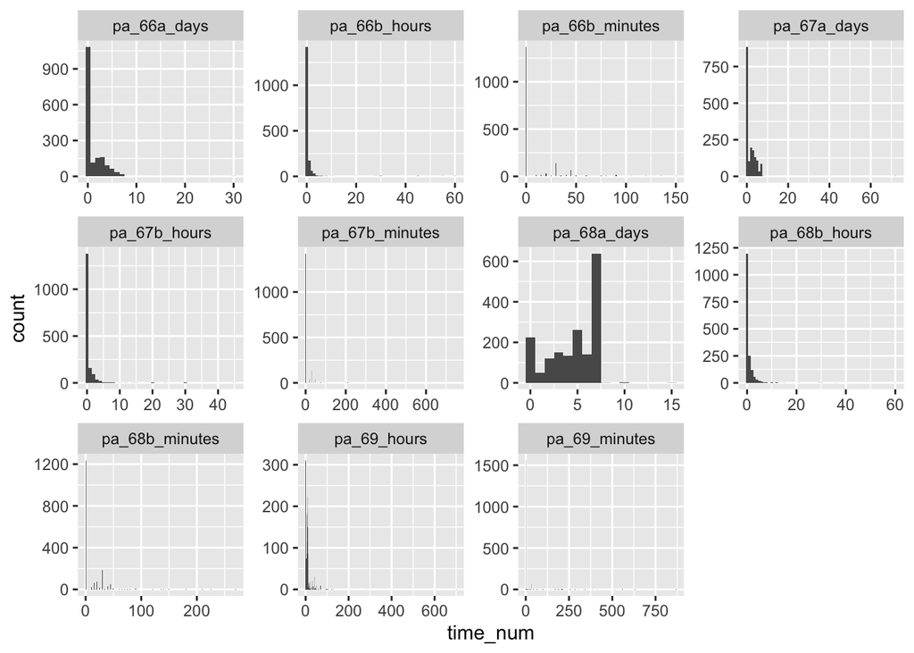

```r
#Looks like all the days variables have outliers (can't have more than 7 days a week).

#To visualize outliers for all IPAQ time variables, will create histograms. Need to create single column with time values using pivot longer, then use facet_wrap to separate histograms for individual variables.
bladderhealth_timevals.df <- bladderhealth.df %>% pivot_longer(all_of(cols), names_to = "time_var", values_to = "time_num")
ggplot(bladderhealth_timevals.df, aes(x = time_num)) + geom_histogram(binwidth = 1) + facet_wrap(~time_var, scales = "free")
```